# R5.01 - Environnement économique : Économie des inégalités

Chapitre 6 : les causes des inégalités — le salaire

Thomas Delcey

thomas.delcey@ube.fr

Université de Bourgogne Europe

### Le problème du chapitre

**Le problème du chapitre**

Dans le chapitre précédent, nous avons fait un tour d’horizon des inégalités économiques dans le monde. Une question centrale demeure: **comment expliquer ces inégalités économiques ?**

Dans ce chapitre, nous allons nous intéresser aux causes des inégalités économiques.

### Expliquer les inégalités économiques

**Le revenu national**

$$Y = F(K,L) = pK + wL$$

- Deux grandes problématiques:
  1. Les inégalités dans le travail $wL$ (par simplification, les salaires) — **ce chapitre** ;
  2. La répartition de la valeur ajoutée entre $pK$ et $wL$ — **chapitre 7**.

Commençons par les inégalités de salaire: comment expliquer les différences de salaires ?

### La théorie du capital humain

**Le capital humain**

Le capital humain est l’ensemble des (i) compétences, (ii) connaissances et (iii) expériences qu’un individu peut acquérir et qui peuvent être valorisées sur le marché du travail.

- La théorie du capital humain de Gary Becker (1964) cherche à expliquer les différences de salaires en termes d’investissement dans l’éducation et la formation.
- Le capital humain est, par analogie avec le capital physique, un stock dans lequel les individus investissent pour accroitre leur productivité et donc leur salaire futur.

### L’investissement dans le capital humain

**Choix rationnel et maximisation**

Selon Becker (1964), l’investissement dans le capital humain est un *choix rationnel*. Dans le cas du capital humain, on cherche à maximiser une fonction $U$ tel que:

$$\max_{h \in H} \; U(h) = B(h) - C(h)
\quad \text{sous une contrainte éventuelle} \quad C(h) \leq Y$$

Avec $B(h)$ les bénéfices attendus de l’investissement dans le capital humain $h$ et $C(h)$ les coûts associés, $H$ l’ensemble des niveaux de capital humain possibles et $Y$ le revenu disponible pour investir dans le capital humain.

- Les coûts $C(h)$ comprennent les frais mais aussi le **coût d’opportunité** de la formation ;
- $B(h)$ est supposé avoir un rendement décroissant et $C(h)$ un coût croissant.

### Intuition graphique

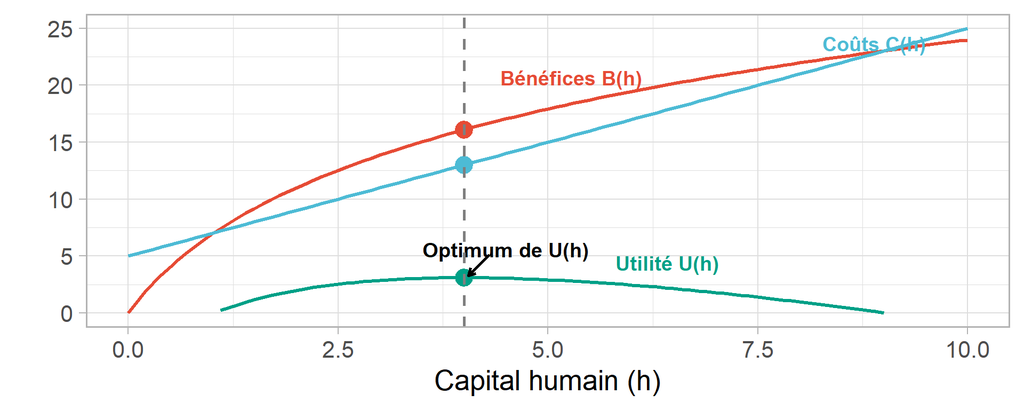

Représentation graphique de l’investissement dans le capital humain

**Deux explications aux inégalités**

1. Les individus diffèrent dans $B(h)$ (par exemple, les capacités cognitives, la motivation, etc.).
2. Les individus diffèrent dans $C(h)$ (par exemple, les frais de scolarité, le soutien familial, etc.).

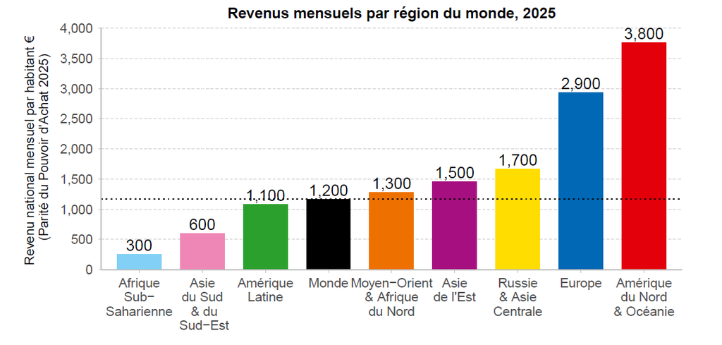

(a) Revenus mensuels moyens

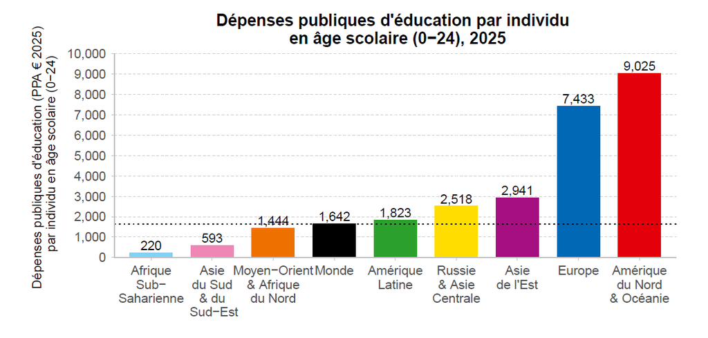

(b) Dépenses publiques d’éducation

Figure 1: Revenu mensuels moyens et dépenses publiques d’éducations dans le monde. Source : Chancel et al. (2025)

### Limites de la théorie du capital humain

**Limites**

- La théorie du capital humain prédit que l’éducation et la formation expliquent la majorité des inégalités de salaires.
- Mais en France, à niveau d’éducation égal, les inégalités de salaires restent très élevées:
  - Causes structurelles (type de contrat, le secteur d’activité, la taille de l’entreprise, les rapports de force, etc.) ;
  - Discrimination (sexe, origine ethnique, etc.) ;
  - Le capital social (accès aux bonnes opportunités).

Autrement dit, le capital humain est une condition nécessaire mais non suffisante pour comprendre les inégalités de salaires. Il existe une multitude d’autres facteurs qui expliquent les inégalités de salaires.

### Le cas des salaires entre hommes et femmes

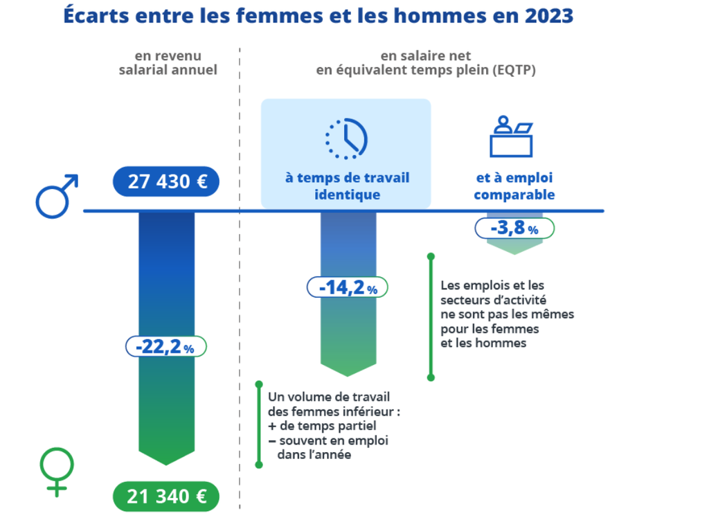

Source: Insee (Gerardin 2025)

**La discrimination pure**

La discrimination pure est une discrimination qui n’est pas justifiée par des différences de qualifications ou de temps de travail.

**Une évolution à la baisse**

- En 1995, l’écart de salaire EQTP entre hommes et femmes était de 22.1%.
- En 2023, il est de 14.2%.

Expliquer statistiquement ces écarts ne veut pas dire les justifier.

### Le rôle central de la maternité

- La maternité est un facteur clé pour expliquer les écarts de salaires entre hommes et femmes.
- Les femmes interrompent ou ralentissent plus souvent leur carrière pour s’occuper des enfants.

**Écart moyen entre hommes et femmes, selon la situation familiale (Gerardin 2025):**

- Ensemble : 22.2% (slide précédente)
- Sans enfant : 13.2% ;
- Avec au moins un enfant : 29.9% ;
- Avec un enfant de moins de 3 ans : 32.0% ;
- Avec au moins trois enfants : 40.9%.

### Le travail domestique aujourd’hui

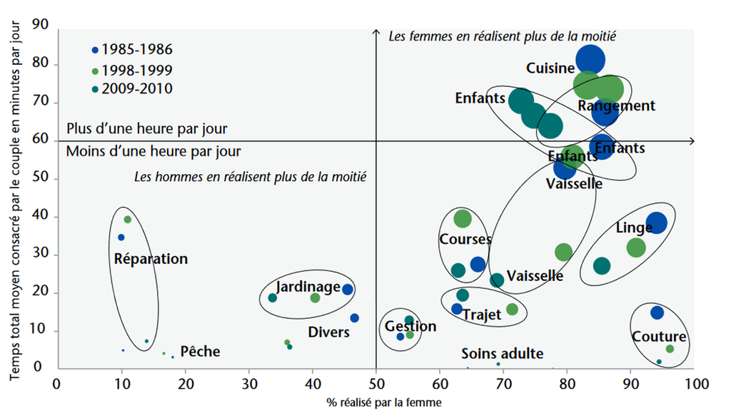

Source: Hélène Périvier (2017), à partir des données de l’INSEE. Prochaine enquête l’année prochaine ;)

### Depuis quand les femmes travaillent-elles ?

**Idée reçue**

- Un cliché répandu est que les femmes auraient commencé à travailler pendant la seconde guerre mondiale, et le phénomène se serait amplifié dans les années 1960-1970.
- Les femmes ont toujours travaillé dans l’Histoire. Ce qui change c’est la reconnaissance sociale et économique de ce travail.

[figure not shown]

Paysanne

[figure not shown]

Boulangère

[figure not shown]

Miresse

Figure 2: Illustration de femmes travaillant au moyen âge, extrait du *Tacuinum Sanitatis* et du *Codex Manesse* (XIVe siècle)

### Le travail des femmes au 19<sup>e</sup> siècle

- Au 19eme siècle, la majorité des femmes travaillent dans les champs et dans les usines ;
- La femme au foyer est un bien de luxe que seule la bourgeoisie peut s’offrir:

> “La place de la femme (selon le schéma idéal de notre système social) en est venue à être celle d’un moyen de dépense ostensiblement improductive.”

Thorstein Veblen (1894, 200) dans *The Economic Theory of Woman’s Dress*

### Le travail des femmes au 20<sup>e</sup> siècle

- Le modèle Monsieur “Gagne-pain” et Madame “Au-Foyer” s’impose dans les années 1950-1960 ;
  - Il est conforté par l’Etat providence (allocations familiales, etc.).
- Fin de ce modèle dans les années 1970-1980:
  - Les mouvements féministes ;
  - Augmentation du niveau d’éducation des femmes ;
  - Contraception & avortement ;
  - Usage croissant du capital dans les ménages.

### L’exemple de la pilule contraceptive

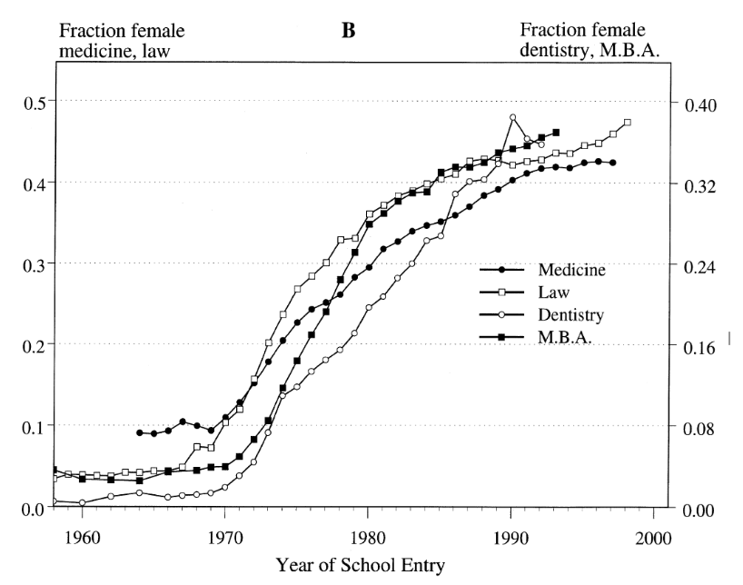

Extrait de Goldin et Katz (2002)

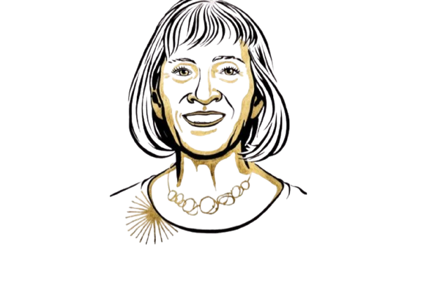

Claudia Goldin, Prix Nobel d’Economie 2023

L’accès à la pilule a (i) retardé l’âge du mariage, (ii) augmenté la part de femmes dans les études longues. La pilule a permis aux femmes de mieux planifier leur carrière professionnelle.

### Les inégalités patrimoniales entre hommes et femmes

**Important**

Une **égalité** en droit mais une **inégalité** dans les faits (Bessière et Gollac 2022; Chatain 2025):

Depuis 1980, la part du patrimoine détenue par les femmes a baissé du fait de la baisse des mariages (mais pas des séparations) et d’héritages inégalitaires.

### Autres facteurs des inégalités de salaires

- Il existe de nombreux autres facteurs qui expliquent les inégalités de salaires, parmi lesquels:
  - **Les inégalités persistantes entre secteurs**
  - **La polarisation du marché du travail**
  - **Le rôle des syndicats et des négociations collectives**
  - **Les inégalités spatiales**

### Inégalités spatiales du revenu en France

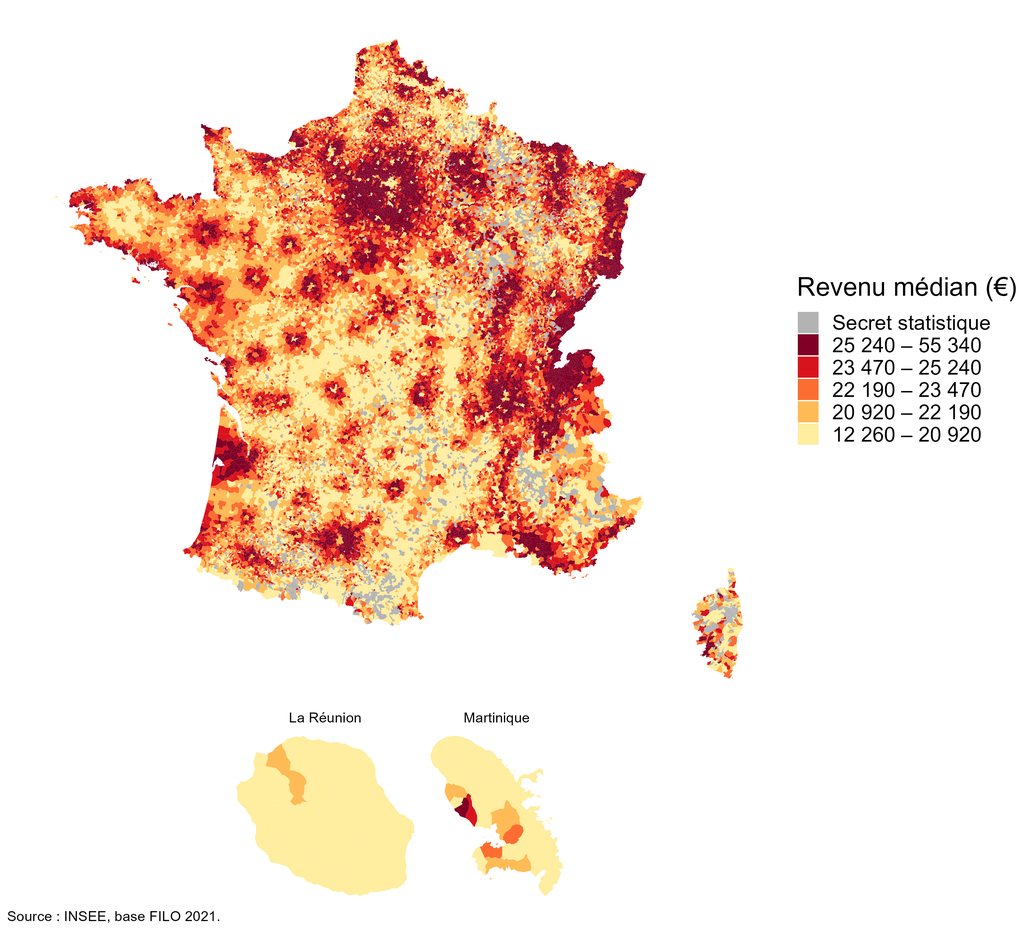

- En moyenne, les villes sont plus riches que les campagnes ;
- Mais la carte est **trompeuse** sur plusieurs aspects:
  - Elle surreprésente les campagnes, peu peuplées, alors que 90 % de la population vit dans une zone d’influence urbaine ;
  - La vie en ville coûte plus cher
  - Il y a plus de riches en ville mais il y aussi plus de pauvres
  - Le péri-urbain a le taux de pauvreté le plus faible

### Références

Becker, Gary S. 1964. *Human Capital: A Theoretical and Empirical Analysis with Special Reference to Education*. First. Cambridge, MA: National Bureau of Economic Research.

Bessière, Céline, et Sibylle Gollac. 2022. *Le genre du capital: comment la famille reproduit les inégalités*. La Découverte.

Chancel, Lucas, Ricardo Gómez-Carrera, Rowaida Moshrif, et Thomas Piketty. 2025. « Rapport sur les inégalités mondiales 2026. Synthèse ». World Inequality Lab; https://wir2026.wid.world.

Chatain, Lise. 2025. *Le sexe de l’impôt : L’impact de la fiscalité sur l’égalité entre les femmes et les hommes*. 1<sup>re</sup> éd. LGDJ.

Gerardin, Mathilde. 2025. « Écart de salaire entre femmes et hommes en 2023 ». Insee Focus, n° 349.

Goldin, Claudia, et Lawrence F. Katz. 2002. « The Power of the Pill: Oral Contraceptives and Women’s Career and Marriage Decisions ». *Journal of Political Economy* 110 (4): 730‑70. https://doi.org/10.1086/340778.

Périvier, Hélène. 2017. « Réduire les inégalités professionnelles en réformant le congé paternité ». Policy Brief 11. OFCE, Sciences Po. https://sciencespo.hal.science/hal-03458937.

Veblen, Thorstein. 1894. « The Economic Theory of Woman’s Dress ». *The Popular Science Monthly* 46: 198‑205. http://www.modetheorie.de/fileadmin/Texte/v/Veblen-The_Economic_Theory_of_Fashion_1894.pdf.